# Yield Curve Inversion

Antonio Giannaccari

2020-10-20

The yield curve plots the yields of bonds of the same credit profile but with different maturities. In other words, it describes the attractiveness of investing in a bond in different time frames. Normally, this line is upward sloping, because long-term bonds tend to have higher higher yields. When this line is downward sloping, it might signify that an economic recession is coming. Below is an analysis of this phenomenon.

First, we will use the `tidyquant` package to download monthly rates for different durations.

```r
# Get a list of FRED codes for US rates and US yield curve; choose monthly frequency
# to see, eg., the 3-month T-bill https://fred.stlouisfed.org/series/TB3MS
tickers <- c('TB3MS', # 3-month Treasury bill (or T-bill)
             'TB6MS', # 6-month
             'GS1',   # 1-year
             'GS2',   # 2-year, etc....
             'GS3',
             'GS5',
             'GS7',
             'GS10',
             'GS20',
             'GS30')  #.... all the way to the 30-year rate

# Turn  FRED codes to human readable variables
myvars <- c('3-Month Treasury Bill',
            '6-Month Treasury Bill',
            '1-Year Treasury Rate',
            '2-Year Treasury Rate',
            '3-Year Treasury Rate',
            '5-Year Treasury Rate',
            '7-Year Treasury Rate',
            '10-Year Treasury Rate',
            '20-Year Treasury Rate',
            '30-Year Treasury Rate')

maturity <- c('3m', '6m', '1y', '2y','3y','5y','7y','10y','20y','30y')

# by default R will sort these maturities alphabetically; but since we want
# to keep them in that exact order, we recast maturity as a factor
# or categorical variable, with the levels defined as we want
maturity <- factor(maturity, levels = maturity)

# Create a lookup dataset
mylookup<-data.frame(symbol=tickers,var=myvars, maturity=maturity)
# Take a look:
mylookup %>%
  knitr::kable()
```

| symbol | var | maturity |
| --- | --- | --- |
| TB3MS | 3-Month Treasury Bill | 3m |
| TB6MS | 6-Month Treasury Bill | 6m |
| GS1 | 1-Year Treasury Rate | 1y |
| GS2 | 2-Year Treasury Rate | 2y |
| GS3 | 3-Year Treasury Rate | 3y |
| GS5 | 5-Year Treasury Rate | 5y |
| GS7 | 7-Year Treasury Rate | 7y |
| GS10 | 10-Year Treasury Rate | 10y |
| GS20 | 20-Year Treasury Rate | 20y |
| GS30 | 30-Year Treasury Rate | 30y |

```r
df <- tickers %>% tidyquant::tq_get(get="economic.data",
                   from="1960-01-01")   # start from January 1960

glimpse(df)
```

```
## Rows: 6,774
## Columns: 3
## $ symbol <chr> "TB3MS", "TB3MS", "TB3MS", "TB3MS", "TB3MS", "TB3MS", "TB3MS",…
## $ date   <date> 1960-01-01, 1960-02-01, 1960-03-01, 1960-04-01, 1960-05-01, 1…
## $ price  <dbl> 4.35, 3.96, 3.31, 3.23, 3.29, 2.46, 2.30, 2.30, 2.48, 2.30, 2.…
```

Our dataframe `df` has three columns (variables):

- `symbol`: the FRED database ticker symbol
- `date`: already a date object
- `price`: the actual yield on that date

Simplifying and merging the data:

```r
yield_curve <-left_join(df,mylookup,by="symbol")
```

# 1 Plotting the yield curve

## 1.1 Yields on US rates by duration since 1960

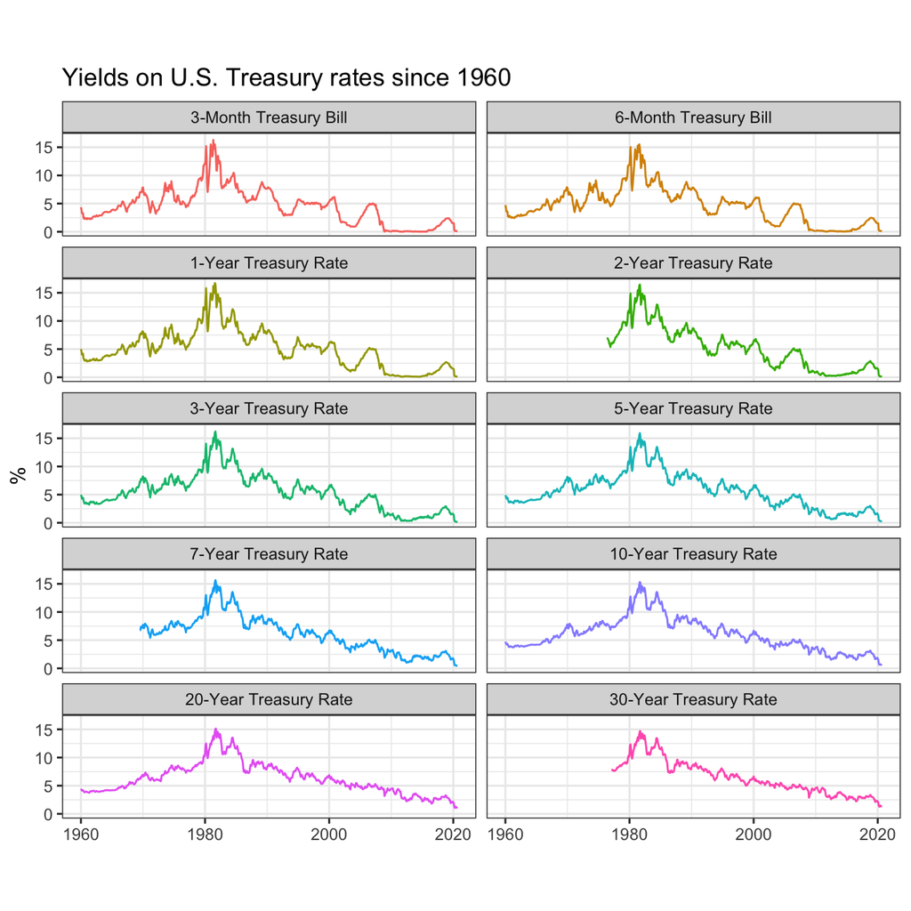

```r
yield_curve$var <- factor(yield_curve$var, levels = c("3-Month Treasury Bill",
                                                                "6-Month Treasury Bill",
                                                                "1-Year Treasury Rate",
                                                                "2-Year Treasury Rate",
                                                                "3-Year Treasury Rate",
                                                                "5-Year Treasury Rate",
                                                                "7-Year Treasury Rate",
                                                                "10-Year Treasury Rate",
                                                                "20-Year Treasury Rate",
                                                                "30-Year Treasury Rate"))

ggplot(yield_curve, aes(x=date, y=price, color=var))+
  geom_line() +
  theme_bw() +
  facet_wrap(~ var, ncol=2) +
  ggtitle("Yields on U.S. Treasury rates since 1960") +
  ylab("%") +
  theme(axis.title.x = element_blank()) +
  theme(aspect.ratio = 1/4) +
  theme(legend.position = "none")
```

## 1.2 Monthly yields on US rates by duration since 1999 on a year-by-year basis

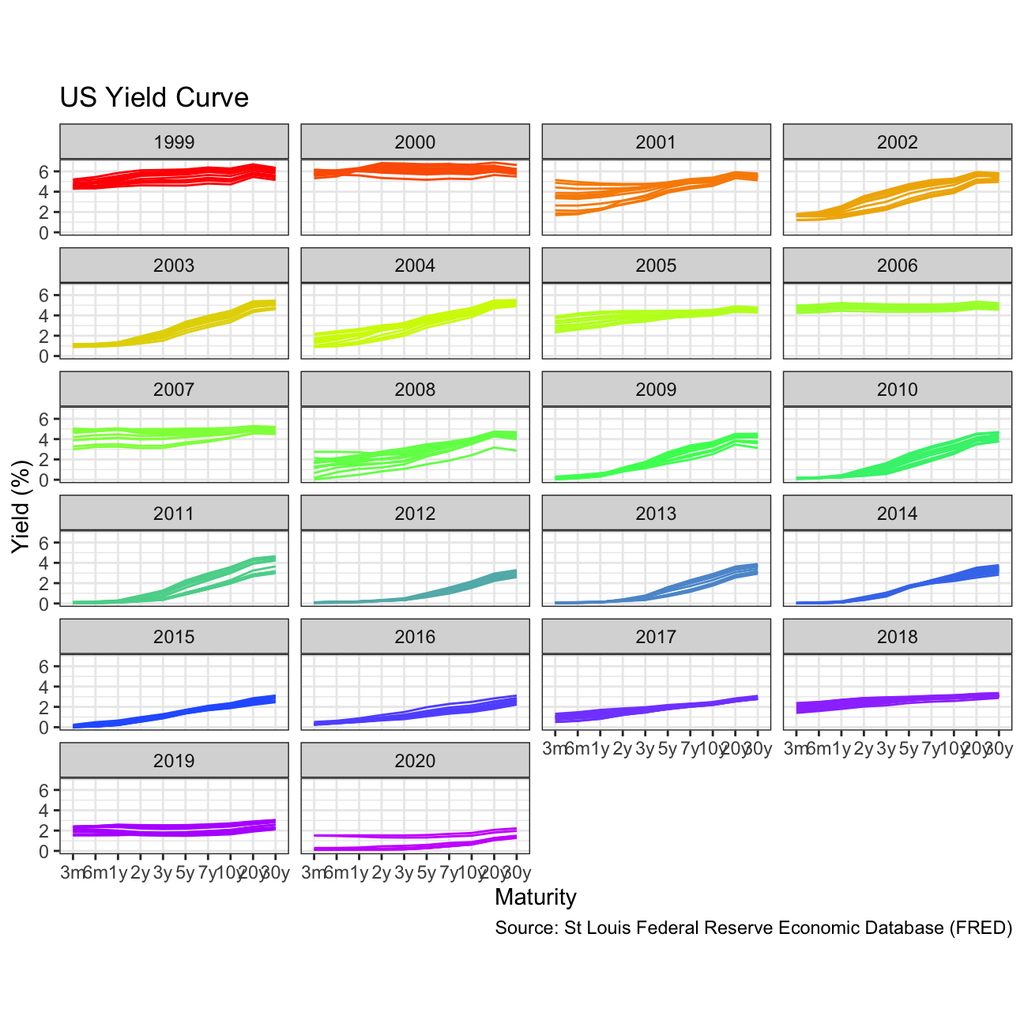

```r
yield_curve$maturity <- factor(yield_curve$maturity, levels = c("3m",
                                                                "6m",
                                                                "1y",
                                                                "2y",
                                                                "3y",
                                                                "5y",
                                                                "7y",
                                                                "10y",
                                                                "20y",
                                                                "30y"))

yield_curve_1999 <- yield_curve %>%
  filter(year(date)>1998) %>%
  mutate(year = year(date))


ggplot(yield_curve_1999, aes(x=maturity, y=price, color=year, group=date)) +
  geom_line() +
  theme_bw() +
  facet_wrap(~ year, ncol=4) +
  ggtitle("US Yield Curve") +
  ylab("Yield (%)") +
  xlab("Maturity") +
  labs(caption = "Source: St Louis Federal Reserve Economic Database (FRED)") +
  theme(aspect.ratio = 1/3) +
  theme(legend.position = "none") +
  scale_color_gradientn(colours = rainbow(5))
```

## 1.3 3-month and 10-year yields since 1999

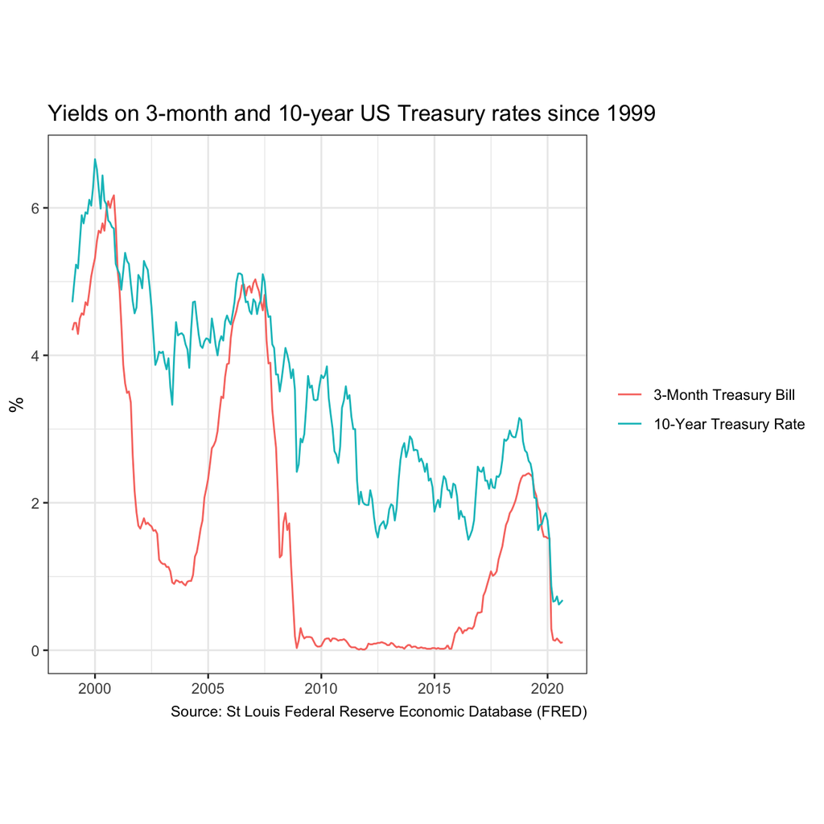

```r
ggplot(filter(yield_curve_1999, maturity %in% c("3m", "10y")), aes(x=date, y=price, color=maturity)) +
  geom_line() +
  theme_bw() +
  ggtitle("Yields on 3-month and 10-year US Treasury rates since 1999") +
  ylab("%") +
  labs(caption = "Source: St Louis Federal Reserve Economic Database (FRED)") +
  theme(axis.title.x = element_blank(),
        legend.title = element_blank(),
        aspect.ratio = 1) +
  scale_color_discrete(labels = c("3-Month Treasury Bill", "10-Year Treasury Rate"))
```

According to [Wikipedia’s list of recession in the United States](https://en.wikipedia.org/wiki/List_of_recessions_in_the_United_States), since 1999 there have been two recession in the US: between Mar 2001–Nov 2001 and between Dec 2007–June 2009. Does the yield curve seem to flatten before these recessions? Can a yield curve flattening really mean a recession is coming in the US? Since 1999, when did short-term (3 months) yield more than longer term (10 years) debt?

The code below creates a dataframe with all US recessions since 1946:

```r
# get US recession dates after 1946 from Wikipedia
# https://en.wikipedia.org/wiki/List_of_recessions_in_the_United_States

recessions <- tibble(
  from = c("1948-11-01", "1953-07-01", "1957-08-01", "1960-04-01", "1969-12-01", "1973-11-01", "1980-01-01","1981-07-01", "1990-07-01", "2001-03-01", "2007-12-01"),
  to = c("1949-10-01", "1954-05-01", "1958-04-01", "1961-02-01", "1970-11-01", "1975-03-01", "1980-07-01", "1982-11-01", "1991-03-01", "2001-11-01", "2009-06-01")
  )  %>%
  mutate(From = ymd(from),
         To=ymd(to),
         duration_days = To-From)

recessions
```

```
## # A tibble: 11 x 5
##    from       to         From       To         duration_days
##    <chr>      <chr>      <date>     <date>     <drtn>
##  1 1948-11-01 1949-10-01 1948-11-01 1949-10-01 334 days
##  2 1953-07-01 1954-05-01 1953-07-01 1954-05-01 304 days
##  3 1957-08-01 1958-04-01 1957-08-01 1958-04-01 243 days
##  4 1960-04-01 1961-02-01 1960-04-01 1961-02-01 306 days
##  5 1969-12-01 1970-11-01 1969-12-01 1970-11-01 335 days
##  6 1973-11-01 1975-03-01 1973-11-01 1975-03-01 485 days
##  7 1980-01-01 1980-07-01 1980-01-01 1980-07-01 182 days
##  8 1981-07-01 1982-11-01 1981-07-01 1982-11-01 488 days
##  9 1990-07-01 1991-03-01 1990-07-01 1991-03-01 243 days
## 10 2001-03-01 2001-11-01 2001-03-01 2001-11-01 245 days
## 11 2007-12-01 2009-06-01 2007-12-01 2009-06-01 548 days
```

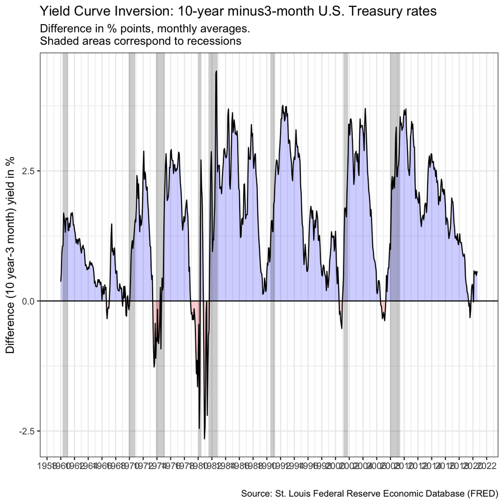

```r
recessions_after_1960 <- recessions %>%
  filter(year(from) >=1960)

graph <- yield_curve %>%
  select(date, symbol, price) %>%
  pivot_wider(names_from = symbol, values_from = price) %>%
  mutate(yield_3m_vs_10y = GS10 - TB3MS)


ggplot(data=graph, aes(x=date, y=yield_3m_vs_10y)) +
  geom_ribbon(aes(ymin=0,ymax=ifelse(yield_3m_vs_10y>0, yield_3m_vs_10y,0)),fill="blue",alpha=0.2) +
  geom_ribbon(aes(ymin=ifelse(yield_3m_vs_10y<0, yield_3m_vs_10y,0),ymax=0),fill="red",alpha=0.2) +
  geom_line() +
  geom_hline(aes(yintercept=0),color="black") +
  geom_rect(data=recessions_after_1960,
            inherit.aes = FALSE,
            aes(ymin=-Inf, ymax= Inf, xmin=From, xmax=To),
            fill = "black",
            alpha = 0.2) +
  theme_bw() +
  labs(title = "Yield Curve Inversion: 10-year minus3-month U.S. Treasury rates",
       subtitle = "Difference in % points, monthly averages.\nShaded areas correspond to recessions",
       caption = "Source: St. Louis Federal Reserve Economic Database (FRED)",
       x="",
       y="Difference (10 year-3 month) yield in %") +
  scale_x_date(date_breaks="2 years",date_labels="%Y")
```

From the graph, it does seem that a negative yield curve (the red parts of the graph) is a fairly convincing signal of an upcoming recession.